# R-INLA를 이용한 공간자료분석 1

# Regression with fixed effect

나무 수 $N_i$는 포아송 분포를 따른다고 가정한다.

$$N_i \sim \text{Poisson}(\lambda_i)$$

$$\log(\lambda_i) = \beta_0 + \beta_1 \cdot \text{elev}_i + \beta_2 \cdot
\text{grad}_i$$

여기서

- $N_i$: $i$번째 격자 셀의 나무 수
- $\lambda_i$: $i$번째 셀의 기대 나무 수
- $\text{elev}_i$: $i$번째 셀의 평균 고도(elevation)
- $\text{grad}_i$: $i$번째 셀의 평균 경사도(gradient)
- $\beta_0$: 절편
- $\beta_1, \beta_2$: 고도 및 경사도의 회귀계수

# Regression with fixed effect

```r
# 모형 1: Poisson 회귀 (공간 효과 없음)
m1 <- inla(Ntrees ~ elev.mean + grad.mean,
           family = "poisson",
           data = bei.df,
           control.compute = list(dic = TRUE, waic = TRUE,
                                  mlik = TRUE,cpo = TRUE))

summary(m1)
```

```
## Time used:
##     Pre = 0.943, Running = 0.163, Post = 0.00747, Total = 1.11
## Fixed effects:
##               mean    sd 0.025quant 0.5quant 0.975quant   mode kld
## (Intercept)  4.699 0.562      3.597    4.699      5.801  4.699   0
## elev.mean   -0.012 0.005     -0.021   -0.012     -0.002 -0.012   0
## grad.mean   18.445 1.684     15.144   18.445     21.746 18.445   0
##
## Deviance Information Criterion (DIC) ...............: 370.25
## Deviance Information Criterion (DIC, saturated) ....: 67.38
## Effective number of parameters .....................: 3.00
##
## Watanabe-Akaike information criterion (WAIC) ...: 371.34
## Effective number of parameters .................: 3.82
##
## Marginal log-Likelihood:  -197.80
## CPO, PIT is computed
## Posterior summaries for the linear predictor and the fitted values are computed
## (Posterior marginals needs also 'control.compute=list(return.marginals.predictor=TRUE)')
```

# random effect

$$N_i \sim \text{Poisson}(\lambda_i)$$

$$\log(\lambda_i) = \beta_0 + \beta_1 \cdot \text{elev}_i + \beta_2 \cdot
\text{grad}_i + u_i$$

$u_i$ : elev 및 grad로 설명하지 못한 나머지 위치의 효과

```r
# 모형 2: RW2D (2차원 2차 랜덤 워크)
m2 <- inla(Ntrees ~ elev.mean + grad.mean +
             f(ID, model = "rw2d", nrow = 5, ncol = 10),
           family = "poisson",
           data = bei.df,
           control.predictor = list(compute = TRUE),
           control.compute = list(dic = TRUE, waic = TRUE,
                                  mlik = TRUE,cpo = TRUE))

summary(m2)
```

[output not shown]

# 랜덤워크기반 random effect 설명 (1차원)

#### i.i.d. 랜덤 효과

$$u_i \stackrel{iid}{\sim} N(0, \, \tau^{-1})$$

각 셀이 독립. 공간 구조 없음.

#### 1차원 RW1

$$u_i - u_{i-1} = \epsilon_i, \quad \epsilon_i \sim N(0, \, \tau^{-1})$$

인접한 값의 차이(기울기)가 $\tau$에 의해 통제된다.

#### 1차원 RW2

$$(u_{i+1} - u_i) - (u_i - u_{i-1}) = \epsilon_i, \quad \epsilon_i \sim
N(0, \, \tau^{-1})$$

기울기의 변화(곡률)가 $\tau$에 의해 통제된다.

# 2차원 확장 (RW2D)

$$\text{가로:} \quad (u_{r,c+1} - u_{r,c}) - (u_{r,c} - u_{r,c-1}) =
\epsilon^{(1)}_{r,c}$$

$$\text{세로:} \quad (u_{r+1,c} - u_{r,c}) - (u_{r,c} - u_{r-1,c}) =
\epsilon^{(2)}_{r,c}$$

$$\text{대각:} \quad (u_{r,c} - u_{r,c-1}) - (u_{r-1,c} - u_{r-1,c-1}) =
\epsilon^{(3)}_{r,c}$$

$$\epsilon^{(k)}_{r,c} \stackrel{iid}{\sim} N(0, \, \tau^{-1}), \quad
k=1,2,3$$

결합 정밀도 행렬:

$$\mathbf{u} \sim N\!\left(\mathbf{0}, \; (\tau \,
\mathbf{Q}_{\text{RW2D}})^{-}\right), \quad
\mathbf{Q}_{\text{RW2D}}
= \mathbf{Q}_1^{(r)} \otimes \mathbf{I}_{n_c}
+ \mathbf{I}_{n_r} \otimes \mathbf{Q}_1^{(c)}
+ \mathbf{Q}_1^{(r)} \otimes \mathbf{Q}_1^{(c)}$$

$\tau$ 크면 부드러운 표면, 작으면 울퉁불퉁한 표면. $\tau$는 데이터로부터 추정.

# 분석결과

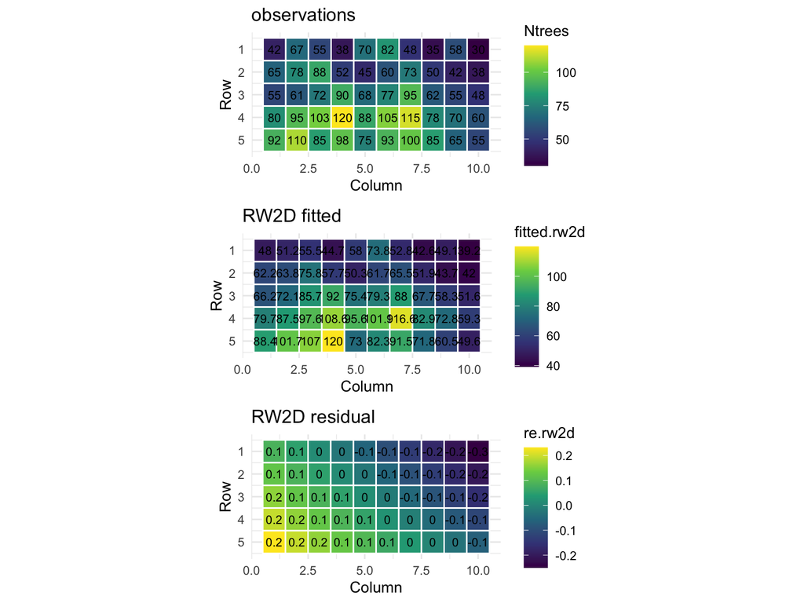

```r
bei.df$fitted.rw2d  <- m2$summary.fitted.values[, "mean"]
bei.df$re.rw2d <- m2$summary.random$ID[, "mean"]


p1 <- plot_heatmap(bei.df, "Ntrees",       "observations")
p2 <- plot_heatmap(bei.df, "fitted.rw2d",  "RW2D fitted")
p3 <- plot_heatmap(bei.df, "re.rw2d", "RW2D residual")
grid.arrange(p1, p2,p3, ncol = 1)
```

# 모델 비교

```
##   Model      DIC     WAIC      mlik     CPO
## 1    m1 370.2503 371.3360 -197.7969 185.696
## 2    m2 363.5951 364.9817 -238.8575 182.627
```

# Irregular Lattice

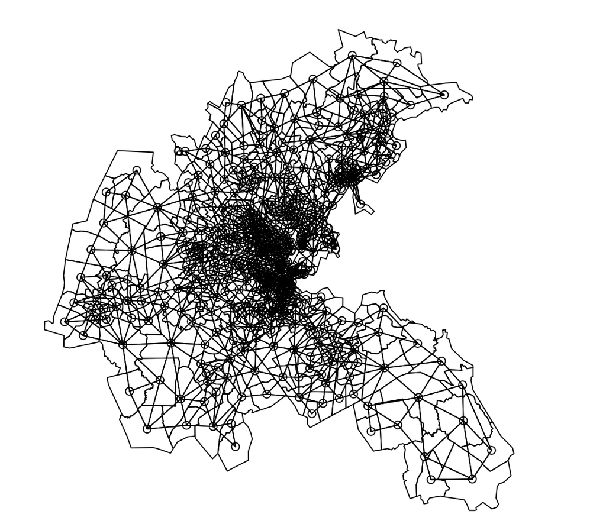

# 데이터 입력

세가지 요소

1. 반응변수
2. 설명변수
3. 인접행렬

```r
library(INLA)
library(ggplot2)
library(gridExtra)

# 데이터프레임: 구획별 반응변수 + 공변량
# boston.df: ID, CMEDV, CRIM, ZN, INDUS, CHAS, NOX, RM, AGE, DIS, RAD, TAX, PTRATIO, B, LSTAT

# 인접 행렬: n×n 이진 대칭 행렬
# W: W[i,j] = 1이면 구획 i와 j가 이웃
```

# Data example

- 예: Boston housing data

```r
library(spData)
library(spdep)
data(boston)
boston.df <- as.data.frame(boston.c)
boston.df$ID <- 1:nrow(boston.df)

# 결측 처리 (CMEDV == 50은 결측치 처리)
boston.df$CMEDV2 <- boston.df$CMEDV
boston.df$CMEDV2[boston.df$CMEDV2 == 50.0] <- NA

W <- nb2mat(boston.soi, style = "B", zero.policy = TRUE)
```

# 예시 데이터

반응변수와 공변량

```r
head(boston.df)
```

```
##         TOWN TOWNNO TRACT      LON     LAT MEDV CMEDV    CRIM ZN INDUS CHAS
## 1     Nahant      0  2011 -70.9550 42.2550 24.0  24.0 0.00632 18  2.31    0
## 2 Swampscott      1  2021 -70.9500 42.2875 21.6  21.6 0.02731  0  7.07    0
## 3 Swampscott      1  2022 -70.9360 42.2830 34.7  34.7 0.02729  0  7.07    0
## 4 Marblehead      2  2031 -70.9280 42.2930 33.4  33.4 0.03237  0  2.18    0
## 5 Marblehead      2  2032 -70.9220 42.2980 36.2  36.2 0.06905  0  2.18    0
## 6 Marblehead      2  2033 -70.9165 42.3040 28.7  28.7 0.02985  0  2.18    0
##     NOX    RM  AGE    DIS RAD TAX PTRATIO      B LSTAT ID CMEDV2
## 1 0.538 6.575 65.2 4.0900   1 296    15.3 396.90  4.98  1   24.0
## 2 0.469 6.421 78.9 4.9671   2 242    17.8 396.90  9.14  2   21.6
## 3 0.469 7.185 61.1 4.9671   2 242    17.8 392.83  4.03  3   34.7
## 4 0.458 6.998 45.8 6.0622   3 222    18.7 394.63  2.94  4   33.4
## 5 0.458 7.147 54.2 6.0622   3 222    18.7 396.90  5.33  5   36.2
## 6 0.458 6.430 58.7 6.0622   3 222    18.7 394.12  5.21  6   28.7
```

# 예시 데이터

인접행렬

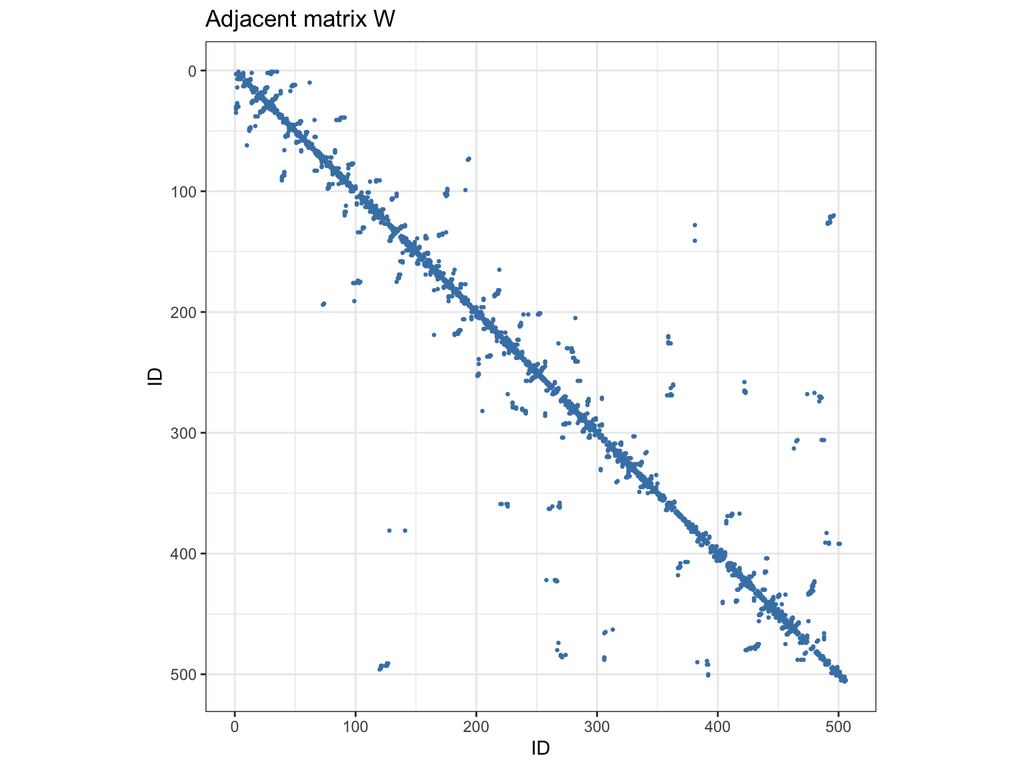

```r
# W를 long format으로 변환
W_df <- as.data.frame(which(W == 1, arr.ind = TRUE))
colnames(W_df) <- c("from", "to")

# 희소 행렬 시각화
ggplot(W_df, aes(x = to, y = from)) +
  geom_point(size = 0.5, color = "steelblue") +
  scale_y_reverse() +
  coord_equal() +
  labs(title = "Adjacent matrix W ",
       x = "ID", y = "ID") +
  theme_bw()
```

# fixed effet model

$$\log(\text{CMEDV}_i) = \beta_0 + \sum_{j=1}^{p} \beta_j x_{ij} +
\varepsilon_i, \quad
\varepsilon_i \stackrel{iid}{\sim} N(0,\ \tau_\varepsilon^{-1})$$

$$\boldsymbol{\beta} = (\beta_0, \beta_1, \ldots, \beta_p)^\top, \quad
\tau_\varepsilon$$

- 오차항의 공간 상관구조 없음: 오차항 $\varepsilon_i$ 독립
- 공변량 $x_{ij}$로 설명되고 남은 잔차의 공간 상관구조 반영 불가

```r
library(INLA)

boston.form <- log(CMEDV2) ~ CRIM + ZN + INDUS + CHAS + I(NOX^2) + I(RM^2) +
  AGE + log(DIS) + log(RAD) + TAX + PTRATIO + B + log(LSTAT)

m.fixed <- inla(boston.form,
                data = boston.df,
                control.compute = list(dic = TRUE, waic = TRUE, cpo = TRUE),
                control.predictor = list(compute = TRUE))

summary(m.fixed)
```

```
## Time used:
##     Pre = 0.793, Running = 0.163, Post = 0.0135, Total = 0.97
## Fixed effects:
##               mean    sd 0.025quant 0.5quant 0.975quant   mode kld
## (Intercept)  4.376 0.151      4.080    4.376      4.672  4.376   0
## CRIM        -0.011 0.001     -0.013   -0.011     -0.009 -0.011   0
## ZN           0.000 0.000     -0.001    0.000      0.001  0.000   0
## INDUS        0.001 0.002     -0.003    0.001      0.006  0.001   0
## CHAS1        0.056 0.034     -0.010    0.056      0.123  0.056   0
## I(NOX^2)    -0.540 0.107     -0.751   -0.540     -0.329 -0.540   0
## I(RM^2)      0.007 0.001      0.005    0.007      0.010  0.007   0
## AGE          0.000 0.001     -0.001    0.000      0.001  0.000   0
## log(DIS)    -0.143 0.032     -0.206   -0.143     -0.080 -0.143   0
## log(RAD)     0.082 0.018      0.047    0.082      0.118  0.082   0
## TAX          0.000 0.000     -0.001    0.000      0.000  0.000   0
## PTRATIO     -0.031 0.005     -0.040   -0.031     -0.021 -0.031   0
## B            0.000 0.000      0.000    0.000      0.001  0.000   0
## log(LSTAT)  -0.329 0.027     -0.382   -0.329     -0.277 -0.329   0
##
## Model hyperparameters:
##                                          mean   sd 0.025quant 0.5quant
## Precision for the Gaussian observations 34.35 2.22      30.14    34.30
##                                         0.975quant  mode
## Precision for the Gaussian observations      38.84 34.21
##
## Deviance Information Criterion (DIC) ...............: -324.39
## Deviance Information Criterion (DIC, saturated) ....: 507.37
## Effective number of parameters .....................: 15.01
##
## Watanabe-Akaike information criterion (WAIC) ...: -317.05
## Effective number of parameters .................: 20.93
##
## Marginal log-Likelihood:  42.90
## CPO, PIT is computed
## Posterior summaries for the linear predictor and the fitted values are computed
## (Posterior marginals needs also 'control.compute=list(return.marginals.predictor=TRUE)')
```

# random effect model

$$\log(\text{CMEDV}_i) = \beta_0 + \sum_{j=1}^{p} \beta_j x_{ij}+ u_i +
\varepsilon_i, \quad
\varepsilon_i \stackrel{iid}{\sim} N(0,\ \tau_\varepsilon^{-1})$$

- $u_i$는 공변량으로 설명되지 않은 부분 중 공간 상관성이 반영된 성분.

```r
# W (인접행렬) → INLA graph 변환
W.mat <- Matrix::Matrix(W, sparse = TRUE)
g <- inla.read.graph(W.mat)

boston.form.re <- log(CMEDV2) ~ CRIM + ZN + INDUS + CHAS + I(NOX^2) + I(RM^2) +
  AGE + log(DIS) + log(RAD) + TAX + PTRATIO + B + log(LSTAT) +
  f(ID, model = "besag", graph = g)

m.besag <- inla(boston.form.re,
                data = boston.df,
                control.compute = list(dic = TRUE, waic = TRUE, cpo = TRUE),
                control.predictor = list(compute = TRUE))

summary(m.besag)
```

```
## Time used:
##     Pre = 0.879, Running = 0.191, Post = 0.0193, Total = 1.09
## Fixed effects:
##               mean    sd 0.025quant 0.5quant 0.975quant   mode kld
## (Intercept)  3.505 0.157      3.196    3.505      3.813  3.505   0
## CRIM        -0.005 0.001     -0.007   -0.005     -0.003 -0.005   0
## ZN           0.000 0.000      0.000    0.000      0.001  0.000   0
## INDUS        0.000 0.002     -0.005    0.000      0.004  0.000   0
## CHAS1       -0.044 0.029     -0.101   -0.044      0.012 -0.044   0
## I(NOX^2)    -0.137 0.146     -0.424   -0.137      0.150 -0.137   0
## I(RM^2)      0.010 0.001      0.008    0.010      0.012  0.010   0
## AGE         -0.001 0.000     -0.002   -0.001      0.000 -0.001   0
## log(DIS)    -0.066 0.066     -0.195   -0.066      0.063 -0.066   0
## log(RAD)     0.056 0.020      0.017    0.056      0.094  0.056   0
## TAX          0.000 0.000     -0.001    0.000      0.000  0.000   0
## PTRATIO     -0.017 0.005     -0.027   -0.017     -0.007 -0.017   0
## B            0.001 0.000      0.001    0.001      0.001  0.001   0
## log(LSTAT)  -0.217 0.023     -0.261   -0.217     -0.172 -0.217   0
##
## Random effects:
##   Name     Model
##     ID Besags ICAR model
##
## Model hyperparameters:
##                                           mean     sd 0.025quant 0.5quant
## Precision for the Gaussian observations 268.13 104.15     131.20   246.90
## Precision for ID                         29.51   5.42      19.66    29.22
##                                         0.975quant   mode
## Precision for the Gaussian observations     532.42 207.86
## Precision for ID                             40.88  29.05
##
## Deviance Information Criterion (DIC) ...............: -1009.62
## Deviance Information Criterion (DIC, saturated) ....: 790.41
## Effective number of parameters .....................: 299.23
##
## Watanabe-Akaike information criterion (WAIC) ...: -990.97
## Effective number of parameters .................: 240.24
##
## Marginal log-Likelihood:  -104.56
## CPO, PIT is computed
## Posterior summaries for the linear predictor and the fitted values are computed
## (Posterior marginals needs also 'control.compute=list(return.marginals.predictor=TRUE)')
```

# 분석결과

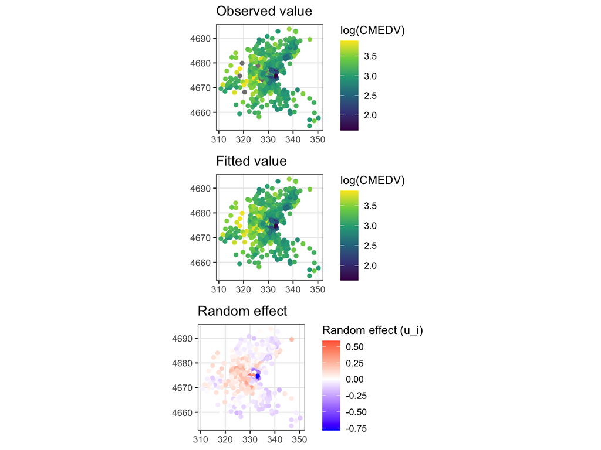

```r
# 좌표 추가 및 sf 변환
boston.df$utm_x <- boston.utm[, 1]
boston.df$utm_y <- boston.utm[, 2]

boston_sf <- st_as_sf(boston.df, coords = c("utm_x", "utm_y"))

# 랜덤효과 + 예측값 추출
boston_sf$re.besag <- m.besag$summary.random$ID[, "mean"]
boston_sf$fitted   <- m.besag$summary.fitted.values[, "mean"]


# 공간 시각화
p1 <- ggplot(boston_sf) +
  geom_sf(aes(color = log(CMEDV2)), size = 1.5) +
  scale_color_viridis_c(name = "log(CMEDV)") +
  labs(title = "Observed value") + theme_bw()

p2 <- ggplot(boston_sf) +
  geom_sf(aes(color = fitted), size = 1.5) +
  scale_color_viridis_c(name = "log(CMEDV)") +
  labs(title = "Fitted value") + theme_bw()

p3 <- ggplot(boston_sf) +
  geom_sf(aes(color = re.besag), size = 1.5) +
  scale_color_gradient2(low = "blue", mid = "white", high = "red",
                        midpoint = 0, name = "Random effect (u_i)") +
  labs(title = "Random effect") + theme_bw()

grid.arrange(p1, p2, p3, ncol = 1)
```

# Model comparison

```r
model_compare <- data.frame(
  Model = c("고정효과만", "Besag 랜덤효과"),
  DIC   = c(m.fixed$dic$dic,   m.besag$dic$dic),
  WAIC  = c(m.fixed$waic$waic, m.besag$waic$waic),
  mlik  = c(m.fixed$mlik[1],   m.besag$mlik[1]),
  CPO   = c(-sum(log(m.fixed$cpo$cpo),  na.rm = TRUE),
            -sum(log(m.besag$cpo$cpo), na.rm = TRUE))
)
```

# 3. Geospatial data

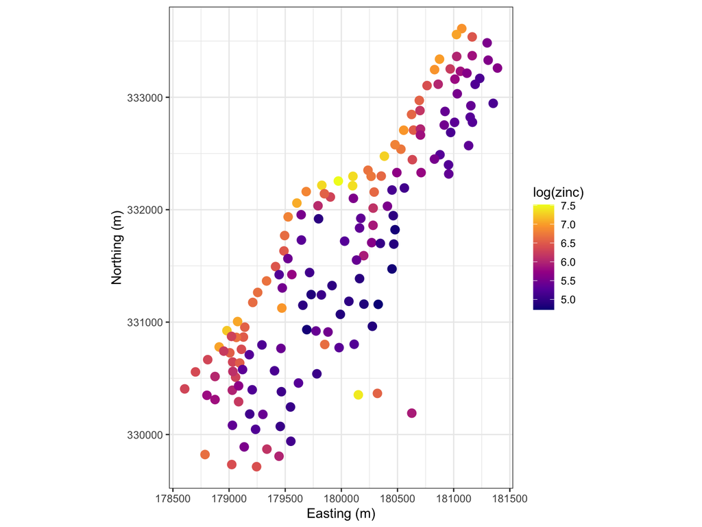

# Data 불러오기

```r
# ============================================================
# (1) 데이터 만들기
# ============================================================
library(gstat); library(sp); library(sf)
library(ggplot2); library(gridExtra); library(INLA)

data(meuse); data(meuse.grid)


meuse_df      <- as.data.frame(meuse)
meuse_grid_df <- as.data.frame(meuse.grid)
```

```r
head(meuse)
```

```
##        x      y cadmium copper lead zinc  elev       dist   om ffreq soil lime
## 1 181072 333611    11.7     85  299 1022 7.909 0.00135803 13.6     1    1    1
## 2 181025 333558     8.6     81  277 1141 6.983 0.01222430 14.0     1    1    1
## 3 181165 333537     6.5     68  199  640 7.800 0.10302900 13.0     1    1    1
## 4 181298 333484     2.6     81  116  257 7.655 0.19009400  8.0     1    2    0
## 5 181307 333330     2.8     48  117  269 7.480 0.27709000  8.7     1    2    0
## 6 181390 333260     3.0     61  137  281 7.791 0.36406700  7.8     1    2    0
##   landuse dist.m
## 1      Ah     50
## 2      Ah     30
## 3      Ah    150
## 4      Ga    270
## 5      Ah    380
## 6      Ga    470
```

```r
head(meuse.grid)
```

```
##        x      y part.a part.b      dist soil ffreq
## 1 181180 333740      1      0 0.0000000    1     1
## 2 181140 333700      1      0 0.0000000    1     1
## 3 181180 333700      1      0 0.0122243    1     1
## 4 181220 333700      1      0 0.0434678    1     1
## 5 181100 333660      1      0 0.0000000    1     1
## 6 181140 333660      1      0 0.0122243    1     1
```

# 관측위치와 grid위치

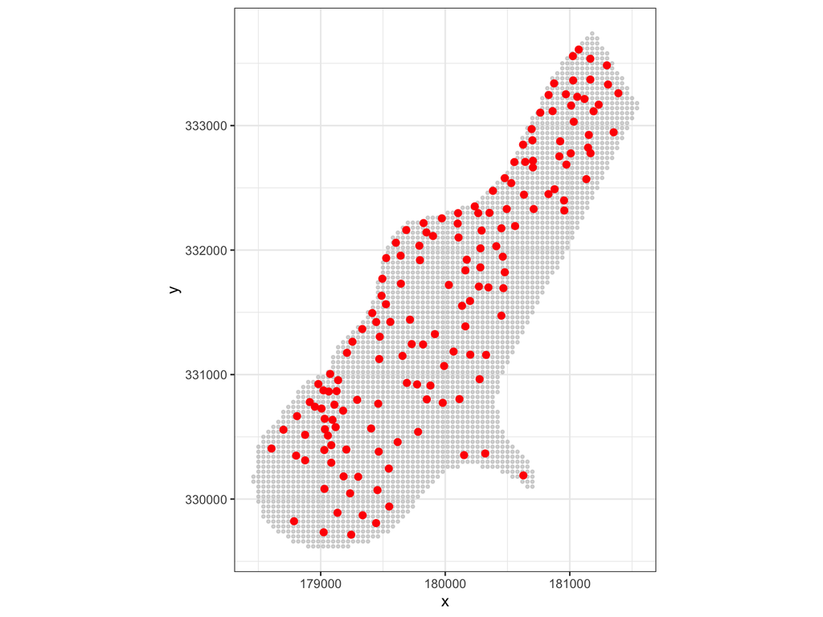

```r
p3 <- ggplot() +
  geom_point(data = meuse_grid_df, aes(x = x, y = y),
             color = "grey70", size = 0.8, alpha = 0.5) +
  geom_point(data = meuse_df, aes(x = x, y = y),
             color = "red", size = 2) +
  coord_equal() + theme_bw()
p3
```

# Fixed effect model

$$\log(\text{zinc}_i) = \beta_0 + \beta_1 \cdot \text{dist}_i +
\varepsilon_i, \quad
\varepsilon_i \stackrel{iid}{\sim} N(0,\ \tau_\varepsilon^{-1})$$

- $\beta_0$: 절편 **(unknown)**
- $\beta_1$: 강까지 거리 효과 **(unknown)**
- $\tau_\varepsilon$: 오차 정밀도 **(unknown)**
- 공변량 $\text{dist}$로 설명되고 남은 **잔차의 공간 상관구조 반영 불가**

```r
# ============================================================
# (3) Fixed Effect Model (공간효과 없음)
# ============================================================
m.fixed <- inla(
  log(zinc) ~ dist,
  family          = "gaussian",
  data            = meuse_df,
  control.compute = list(dic = TRUE, waic = TRUE, cpo = TRUE),
  control.predictor = list(compute = TRUE)
)

summary(m.fixed)
```

```
## Time used:
##     Pre = 0.798, Running = 0.153, Post = 0.00515, Total = 0.955
## Fixed effects:
##               mean    sd 0.025quant 0.5quant 0.975quant   mode kld
## (Intercept)  6.534 0.062      6.413    6.534      6.655  6.534   0
## dist        -2.700 0.198     -3.089   -2.700     -2.310 -2.700   0
##
## Model hyperparameters:
##                                         mean    sd 0.025quant 0.5quant
## Precision for the Gaussian observations 4.26 0.484       3.37     4.24
##                                         0.975quant mode
## Precision for the Gaussian observations       5.26 4.21
##
## Deviance Information Criterion (DIC) ...............: 221.18
## Deviance Information Criterion (DIC, saturated) ....: 160.44
## Effective number of parameters .....................: 3.00
##
## Watanabe-Akaike information criterion (WAIC) ...: 221.46
## Effective number of parameters .................: 3.17
##
## Marginal log-Likelihood:  -124.71
## CPO, PIT is computed
## Posterior summaries for the linear predictor and the fitted values are computed
## (Posterior marginals needs also 'control.compute=list(return.marginals.predictor=TRUE)')
```

# Random effect model - Mesh 구성

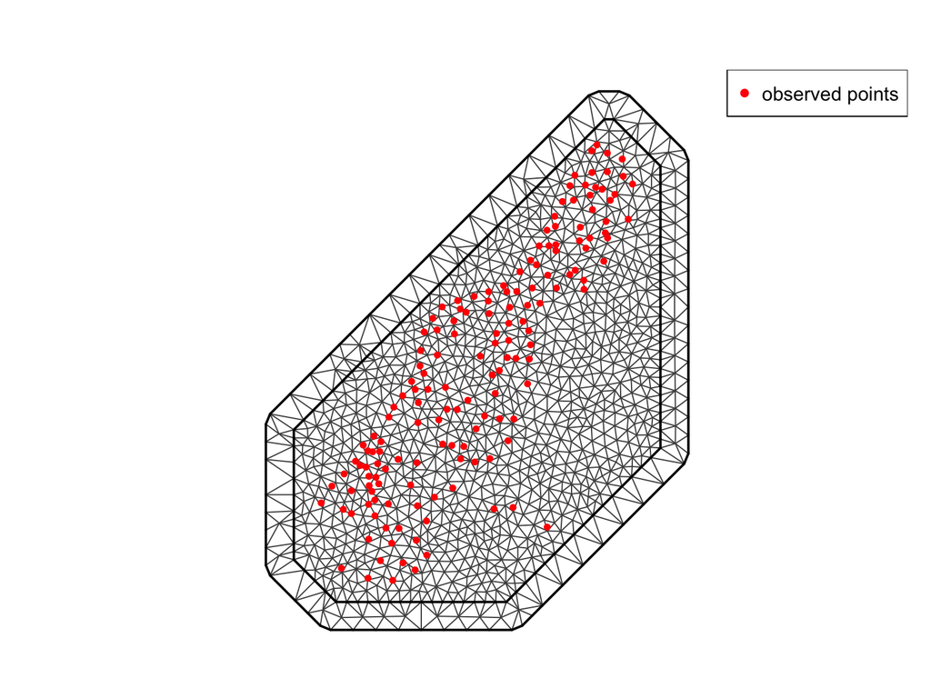

```
## 꼭짓점 수 K = 1172
```

```
## 삼각형 수  = 2268
```

# Data Model

$$\log(\text{zinc}_i) = \beta_0 + \beta_1 \cdot \text{dist}_i + u(s_i) +
\varepsilon_i, \quad
\varepsilon_i \stackrel{iid}{\sim} N(0,\ \tau_\varepsilon^{-1})$$

$\beta_0, \beta_1$: 고정효과 계수 **(unknown)**. $\tau_\varepsilon$: 오차 정밀도 **(unknown)**.

#### 공간 랜덤효과

$$u(s) = \sum_{k=1}^{K} \psi_k(s) \cdot w_k$$

- $\psi_k(s)$: 위치 $s$에서 꼭짓점 $k$로부터 받는 영향의 크기를 나타내는 함수 → **고정** (기하학으로 결정). 임의 위치 $s$에서는 속한 삼각형의 꼭짓점 3개만 관여하도록 $\psi_k(s)$를 설정한다.
  - $s$를 포함하는 삼각형에 꼭지점 $k$가 없으면 $\psi_k(s)=0$를 만족하도록,
  - $s$를 포함하는 삼각형에 꼭지점 $k$가 있으면 $\psi_k(s)>0$ 그리고 가까울수록 큰 값이 되도록.
- $w_k$: 꼭짓점 $k$의 영향력 → **unknown** ($K$개 추정)

# $w_k$의 사전분포 (SPDE)

$$\mathbf{w} \sim \mathcal{N}\!\left(\mathbf{0},\ Q(\theta_1,
\theta_2)^{-1}\right), \quad
Q(\theta_1,\theta_2) = e^{\theta_2}\left(e^{2\theta_1} \mathbf{C} +
\mathbf{G}\right)^2$$

# 추정 대상 요약

| 파라미터 | 의미 | 추정 방법 |
| --- | --- | --- |
| $\beta_0,\ \beta_1$ | 고정효과 계수 | 조건부 가우시안 |
| $\tau_\varepsilon$ | 오차 정밀도 | Laplace 근사 |
| $\kappa,\ \tau$ | 공간 상관 구조 | Laplace 근사 |
| $w_1,\ldots,w_K$ | 꼭짓점 공간효과 | 조건부 가우시안 |

# Projector Matrix A 구성

#### 역할

관측점 $s_i$에서의 공간효과를 꼭짓점 $w_k$의 선형보간으로 연결:

$$\mathbf{u}_\text{obs} = \mathbf{A}_\text{obs} \cdot \mathbf{w}, \qquad
A_{ik} = \psi_k(s_i)$$

$$\mathbf{A}_\text{obs} : (n \times K), \quad \text{각 행에 non-zero 원소
3개만 존재}$$

#### 구조

$$\mathbf{A} = \begin{pmatrix}
0 & \cdots & a_{1j} & a_{1k} & a_{1l} & \cdots &
0 \\
0 & \cdots & 0 & a_{2j} & a_{2k} & a_{2l} & 0 \\
\vdots & & & & & & \vdots
\end{pmatrix}, \quad a_{ij} + a_{ik} + a_{il} = 1$$

- 관측용 $\mathbf{A}_\text{obs}$: 학습에 사용 $(n \times K)$
- 예측용 $\mathbf{A}_\text{pred}$: 격자점 예측에 사용 $(m \times K)$
- **데이터 없이 기하학만으로 계산 → 고정**

# Projector Matrix A 구성

```r
A.obs  <- inla.spde.make.A(mesh,
                            loc = as.matrix(meuse_df[, c("x","y")]))
A.pred <- inla.spde.make.A(mesh,
                            loc = as.matrix(meuse_grid_df[, c("x","y")]))

cat("A.obs 크기:", nrow(A.obs),  "×", ncol(A.obs),  "\n")
```

```
## A.obs 크기: 155 × 1172
```

```r
cat("A.pred 크기:", nrow(A.pred), "×", ncol(A.pred), "\n")
```

```
## A.pred 크기: 3103 × 1172
```

```r
# 1번 관측점 확인
nonzero <- which(A.obs[1, ] != 0)
cat("1번 관측점 활성 꼭짓점:", nonzero, "\n")
```

```
## 1번 관측점 활성 꼭짓점: 330 557 944
```

```r
cat("barycentric 가중치 합 =", sum(A.obs[1, nonzero]), "\n")
```

```
## barycentric 가중치 합 = 1
```

# Random effect model 추론

```r
# SPDE (w의 사전분포 정의)
meuse.spde <- inla.spde2.matern(mesh = mesh)
s.index    <- inla.spde.make.index("spatial.field",
                                    n.spde = meuse.spde$n.spde)

# Stack 구성
stack.obs <- inla.stack(
  data    = list(zinc = meuse_df$zinc),
  A       = list(A.obs, 1),
  effects = list(c(s.index, list(Intercept = 1)),
                 list(dist = meuse_df$dist)),
  tag = "obs"
)

# INLA 추정
m.spde <- inla(
  log(zinc) ~ -1 + Intercept + dist + f(spatial.field, model = meuse.spde),
  data              = inla.stack.data(stack.obs, spde = meuse.spde),
  family            = "gaussian",
  control.predictor = list(A = inla.stack.A(stack.obs), compute = TRUE),
  control.compute   = list(dic = TRUE, waic = TRUE, cpo = TRUE)
)
```

# Random effect model 추론

```
## Time used:
##     Pre = 0.93, Running = 0.33, Post = 0.0311, Total = 1.29
## Fixed effects:
##             mean    sd 0.025quant 0.5quant 0.975quant   mode kld
## Intercept  6.593 0.173      6.251    6.590      6.948  6.590   0
## dist      -2.764 0.416     -3.576   -2.769     -1.923 -2.768   0
##
## Random effects:
##   Name     Model
##     spatial.field SPDE2 model
##
## Model hyperparameters:
##                                          mean    sd 0.025quant 0.5quant
## Precision for the Gaussian observations 12.30 2.833       7.66    11.99
## Theta1 for spatial.field                 4.79 0.282       4.24     4.79
## Theta2 for spatial.field                -5.30 0.330      -5.95    -5.30
##                                         0.975quant  mode
## Precision for the Gaussian observations      18.75 11.39
## Theta1 for spatial.field                      5.35  4.79
## Theta2 for spatial.field                     -4.65 -5.29
##
## Deviance Information Criterion (DIC) ...............: 124.13
## Deviance Information Criterion (DIC, saturated) ....: 223.62
## Effective number of parameters .....................: 66.32
##
## Watanabe-Akaike information criterion (WAIC) ...: 127.59
## Effective number of parameters .................: 55.09
##
## Marginal log-Likelihood:  -110.90
## CPO, PIT is computed
## Posterior summaries for the linear predictor and the fitted values are computed
## (Posterior marginals needs also 'control.compute=list(return.marginals.predictor=TRUE)')
```